# Philippines Population Data

JMT

2023-07-31

## Import Packages

```r
library(dplyr)
library(readr)
library(lubridate)
```

```r
library(ggplot2)
```

## Import Population Data

This data is in a ‘.csv’ format scrapped from [macrotrends.net](https://www.macrotrends.net/countries/PHL/philippines/population).

```r
population_data <- read_csv("Population_1950-2023.csv")
```

## Summarizing Data to have an Overview

Using ‘functions’ to have an overview of the data and get familiarize with it. The following code was used:

```r
glimpse(population_data)
```

```
## Rows: 74
## Columns: 3
## $ Year          <dbl> 2023, 2022, 2021, 2020, 2019, 2018, 2017, 2016, 2015, 20…
## $ Population    <dbl> 117337368, 115559009, 113880328, 112190977, 110380804, 1…
## $ `Growth Rate` <chr> "1.54%", "1.47%", "1.51%", "1.64%", "1.67%", "1.71%", "1…
```

```r
str(population_data)
```

```
## spc_tbl_ [74 × 3] (S3: spec_tbl_df/tbl_df/tbl/data.frame)
##  $ Year       : num [1:74] 2023 2022 2021 2020 2019 ...
##  $ Population : num [1:74] 1.17e+08 1.16e+08 1.14e+08 1.12e+08 1.10e+08 ...
##  $ Growth Rate: chr [1:74] "1.54%" "1.47%" "1.51%" "1.64%" ...
##  - attr(*, "spec")=
##   .. cols(
##   ..   Year = col_double(),
##   ..   Population = col_number(),
##   ..   `Growth Rate` = col_character()
##   .. )
##  - attr(*, "problems")=<externalptr>
```

```r
summary(population_data)
```

```
##       Year        Population        Growth Rate
##  Min.   :1950   Min.   : 18469878   Length:74
##  1st Qu.:1968   1st Qu.: 35778022   Class :character
##  Median :1986   Median : 56762506   Mode  :character
##  Mean   :1986   Mean   : 61314817
##  3rd Qu.:2005   3rd Qu.: 85847813
##  Max.   :2023   Max.   :117337368
```

Note: After having an overview of the data, we have seen that the ‘Year’, ‘Growth Rate’, and ‘Population’ column is in another data type that might cause an error later on.

We make use of the package ‘lubridate’ to convert the column’s data type to a more appropriate type.

```r
year_data <- year(as.Date(as.character(population_data$Year),
                     format = "%Y"))
```

Note: We store the converted data into a new variable so we can reuse it

## Store ‘Population’ to a new Variable

Using ‘as.numeric’ to make sure the data is in a correct data type

```r
population <- as.numeric(population_data$Population)
```

## Investigate More

After more investigation, we also notice that the ‘Growth Rate’ column is in a string data type. We can’t directly convert it to double since it includes ‘%’ sign in it. So we need to remove it first. We use the following code:

```r
growth_rate <- gsub('%', '', population_data$`Growth Rate`)
```

```r
growth_rate <- as.numeric(growth_rate)
```

## Compile the Cleaned Data

Now that we have cleaned the data, we will now compile it in a ‘data frame’ to be able to use it in a chart.

```r
population_df <- data_frame(year_data, population, growth_rate)
```

Now let’s summarize it once again, and scan through the data to know if it’s ready to be plotted.

```r
summary(population_df)
```

```
##    year_data      population         growth_rate
##  Min.   :1950   Min.   : 18469878   Min.   :0.000
##  1st Qu.:1968   1st Qu.: 35778022   1st Qu.:1.913
##  Median :1986   Median : 56762506   Median :2.425
##  Mean   :1986   Mean   : 61314817   Mean   :2.534
##  3rd Qu.:2005   3rd Qu.: 85847813   3rd Qu.:2.708
##  Max.   :2023   Max.   :117337368   Max.   :4.570
```

```r
glimpse(population_df)
```

```
## Rows: 74
## Columns: 3
## $ year_data   <dbl> 2023, 2022, 2021, 2020, 2019, 2018, 2017, 2016, 2015, 2014…
## $ population  <dbl> 117337368, 115559009, 113880328, 112190977, 110380804, 108…
## $ growth_rate <dbl> 1.54, 1.47, 1.51, 1.64, 1.67, 1.71, 1.78, 1.79, 1.68, 1.63…
```

```r
str(population_df)
```

```
## tibble [74 × 3] (S3: tbl_df/tbl/data.frame)
##  $ year_data  : num [1:74] 2023 2022 2021 2020 2019 ...
##  $ population : num [1:74] 1.17e+08 1.16e+08 1.14e+08 1.12e+08 1.10e+08 ...
##  $ growth_rate: num [1:74] 1.54 1.47 1.51 1.64 1.67 1.71 1.78 1.79 1.68 1.63 ...
```

```r
head(population_df)
```

```
## # A tibble: 6 × 3
##   year_data population growth_rate
##       <dbl>      <dbl>       <dbl>
## 1      2023  117337368        1.54
## 2      2022  115559009        1.47
## 3      2021  113880328        1.51
## 4      2020  112190977        1.64
## 5      2019  110380804        1.67
## 6      2018  108568836        1.71
```

## Plotting the data

Now that the data is cleaned and ready, we have to find out what the data is telling. The following code is used:

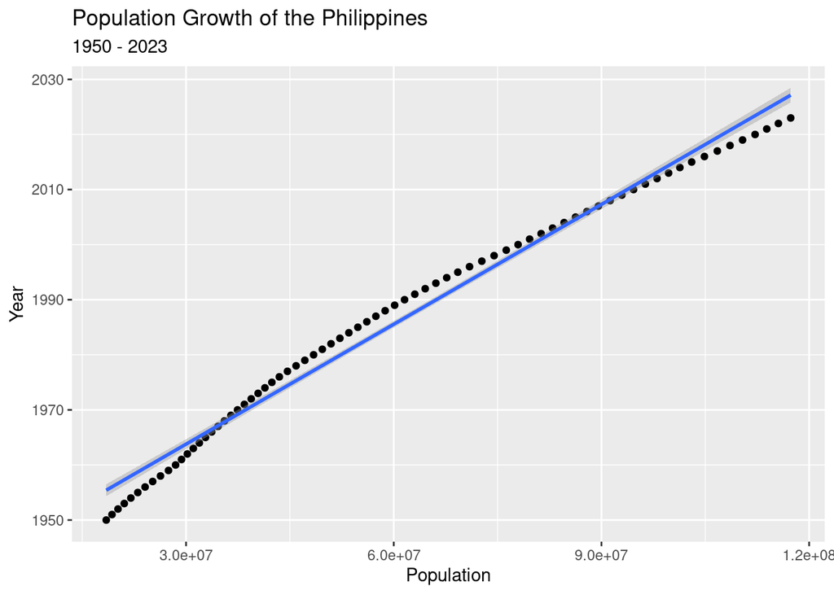

```r
ggplot(data = population_df, aes(x = population, y = year_data)) +
  geom_point() +
  geom_smooth(aes(),method = "lm") +
  labs(x = "Population", y = "Year",title = "Population Growth of the Philippines",
       subtitle = "1950 - 2023")
```

After visualizing the data, we noticed that the ‘Population’ in the **x-axis** is hard to read since it is in *scientific notation format*. So we need to turn it off, and only display the approximate value. The following code is used:

```r
#importing scales package
library(scales)
```

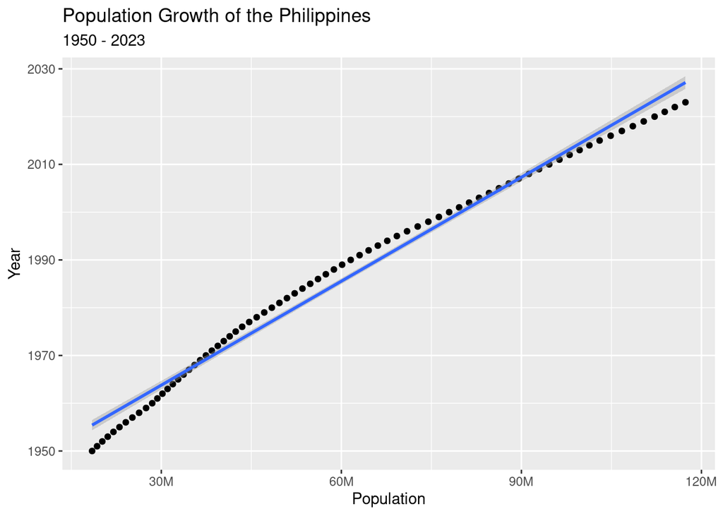

```r
options(scipen = 999)
ggplot(data = population_df, aes(x = population, y = year_data)) +
  geom_point() +
  geom_smooth(aes(),method = "lm") +
  labs(x = "Population", y = "Year",title = "Population Growth of the Philippines",
       subtitle = "1950 - 2023") +
  scale_x_continuous(labels = scales::label_number_si())
```

We also need to visualize ‘Growth Rate’ per ‘Year’. The following code is used:

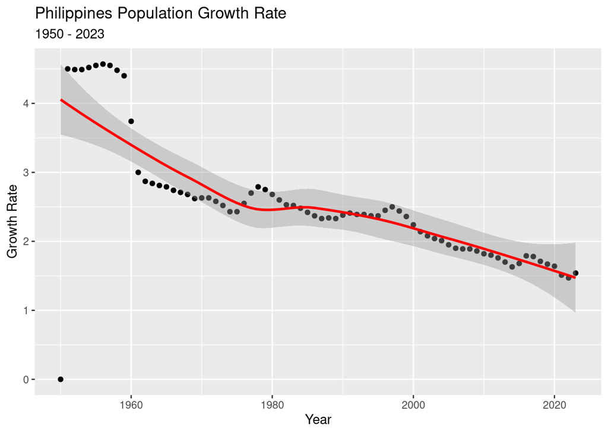

```r
#plotting data for growth rate and year
ggplot(population_df) +
  geom_point(aes(x = year_data, y = growth_rate)) +
  geom_smooth(aes(x = year_data, y = growth_rate), color = "red") +
  labs(x = "Year", y = "Growth Rate",title = "Philippines Population Growth Rate",
       subtitle = "1950 - 2023")
```

## Conclusion and Recommendation

Strategies aimed at encouraging family planning, supporting working-age populations, and promoting innovation and productivity can help maintain a healthy and resilient population. By understanding the nuances of this demographic trend and implementing proactive measures, we can ensure a better future for our communities and foster an environment of well-being and progress.